# Fake News Neural Net Predictor

### Exploratory Data Analysis

Remember that if an article is real, it’s 1, else if fake it’s 0. Here we can see the distrbution of fake and real articles, and notice that the number of fake articles outweight the number of real articles.

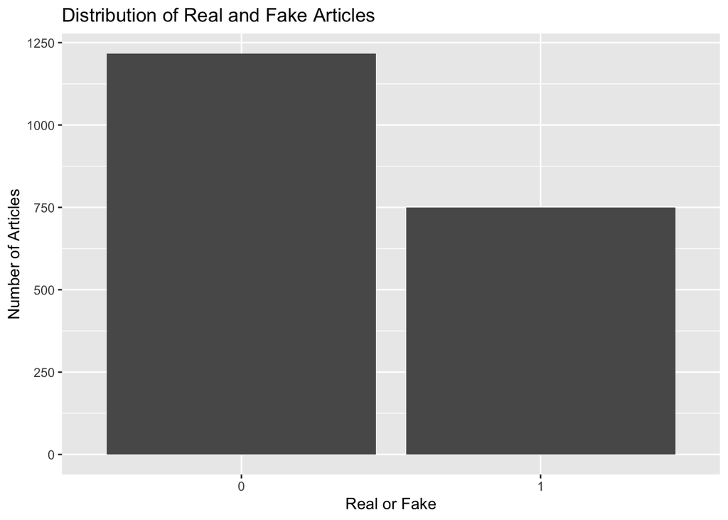

```r
data %>%
  ggplot(aes(x = label)) +
  geom_bar() +
  labs(x = "Real or Fake", y = "Number of Articles", title = "Distribution of Real and Fake Articles")
```

Similarly, we can view the distribution of the type of articles. It seems there is highest number of bs and lowest for fake.

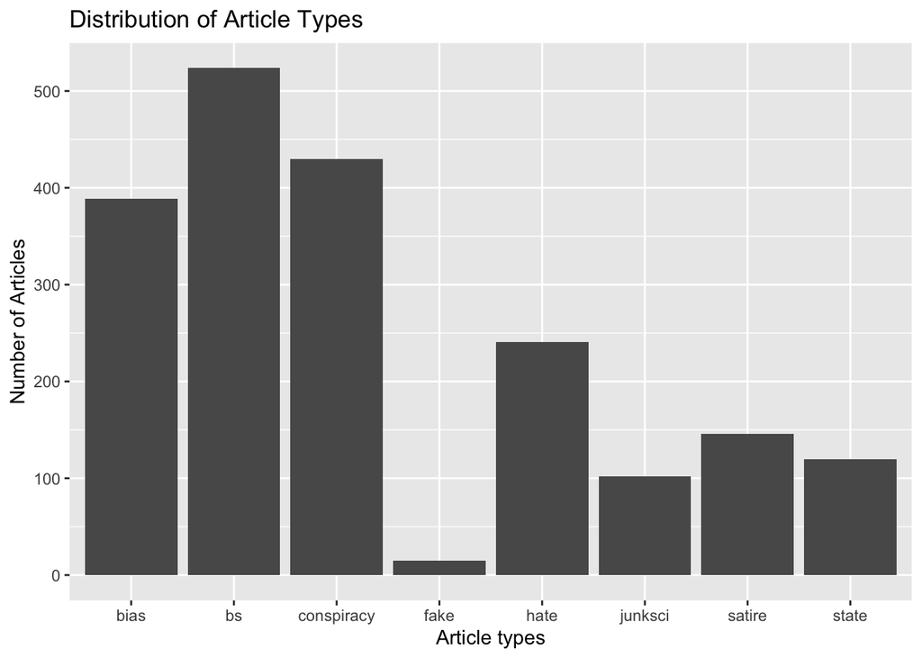

```r
data %>%
  ggplot(aes(x = type)) +
  geom_bar() +
  labs(x = "Article types", y = "Number of Articles", title = "Distribution of Article Types")
```

We can also compare the types against labels. It seems like articles labeled fake are either bs, conspiracy, fake, junksci, or satire, whereas articles labeled real are labeled bias, hate, or state.

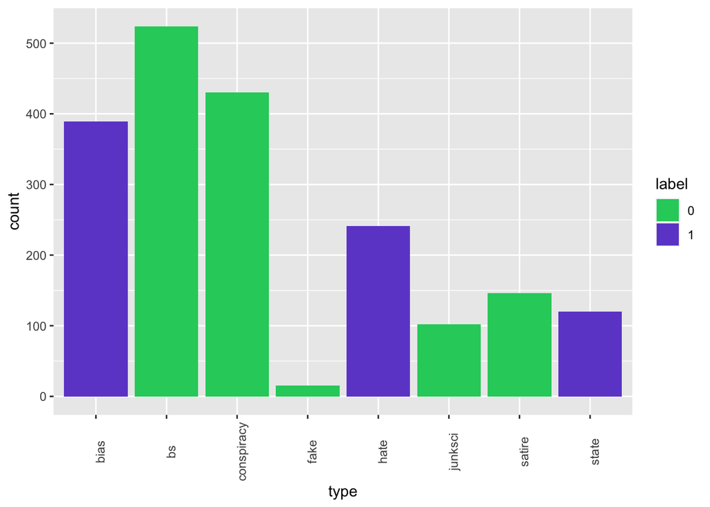

```r
ggplot(data, aes(type)) +
  geom_bar(aes(fill = label)) +
  scale_fill_manual(values = c("#23CE6B", "#6E4ED0")) +
  theme(axis.text.x = element_text(angle = 90))
```

For this dataset, making a correlation plot is actually not feasible because the only numeric predictor is time – the rest are text that would better be done through an nlp neural network.

Instead, we will visualize the predictors compared to the label. Keeping in mind that with the label outcome variable a real article is marked as 1, and a fake article is marked as 0.

First we analyze the site urls. It seems that all sites are either majorly real or majorly fake, while some sites have a few outliering articles that are labeled the opposite of what option (real/fake) they usually publish.

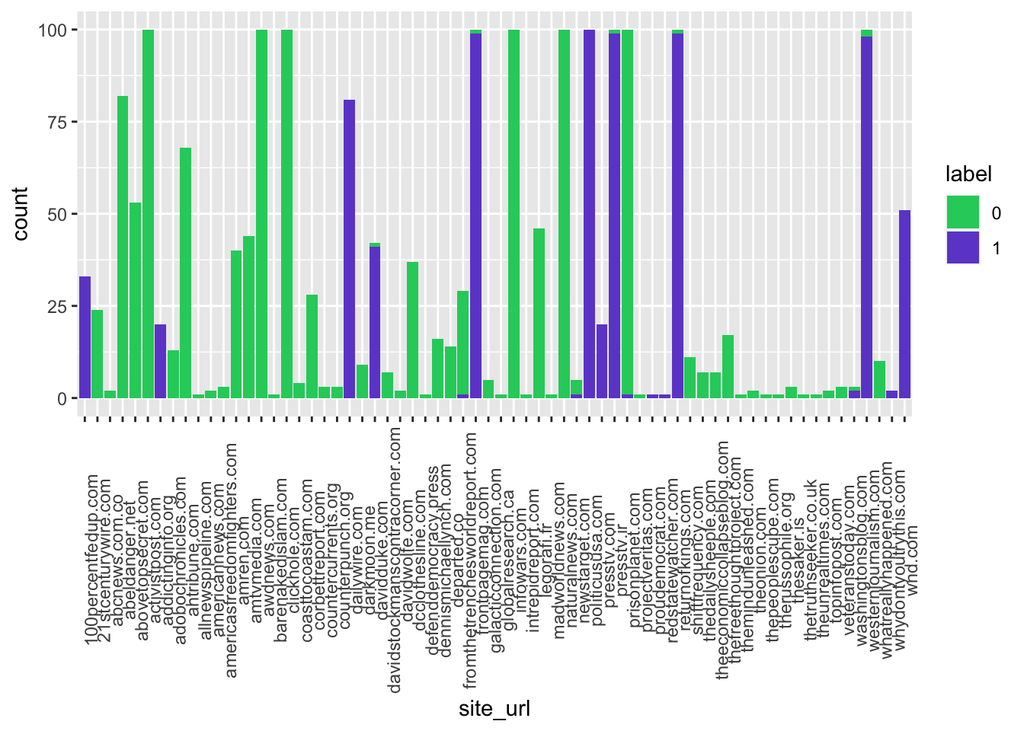

```r
ggplot(data, aes(site_url)) +
  geom_bar(aes(fill = label)) +
  scale_fill_manual(values = c("#23CE6B", "#6E4ED0")) +
  theme(axis.text.x = element_text(angle = 90))
```

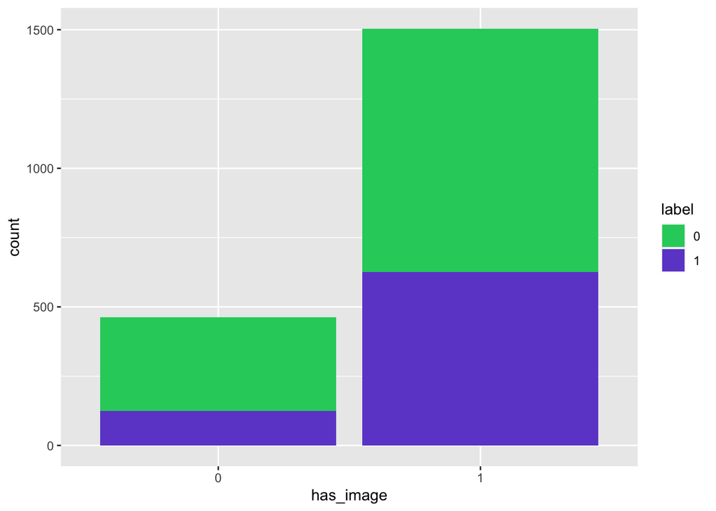

```r
ggplot(data, aes(has_image)) +
  geom_bar(aes(fill = label)) +
  scale_fill_manual(values = c("#23CE6B", "#6E4ED0"))
```

Now published month can be assessed. There are only months 10, 11 (October and November). There seems to be a somewhat equal proportion of the months distributed, so months may not be a very strong predictor either.

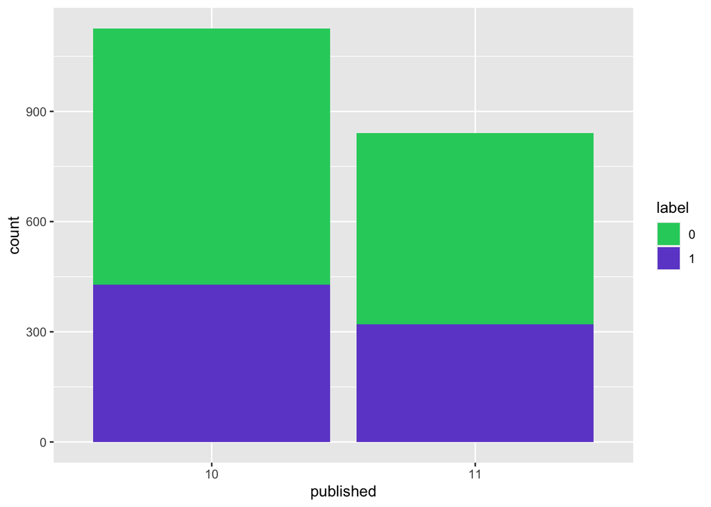

```r
ggplot(data, aes(published)) +
  geom_bar(aes(fill = label)) +
  scale_fill_manual(values = c("#23CE6B", "#6E4ED0"))
```

The other data such as title, title_without_stopwords, text, and text_without_stopwords, don’t make as much sense to visualize in this way.

### Setting up Models

```r
data_simple <- subset(data, select = -c(title, title_without_stopwords, text, text_without_stopwords))
```

### Train and Test Split

Now, I will split the data into a training set and a testing set. I have decided to do 80% to 20% split, as our dataset is pretty large and will have plenty of testing data while being able to have more data to train on. The reason I split is to avoid overfitting – using 80% of the datset to train, and then having the 20% as testing dataset can help determine if the model is good at predicting new data and not overfit to only the current dataset it was fed. We stratify the data to “label”.

```r
#split data stratified to label (real/fake)
data_simple_split <- data_simple %>%
  initial_split(prop = 0.8, strata = "label")

data_train <- training(data_simple_split) # training split for label
data_test <- testing(data_simple_split) # testing split for label
```

```r
dim(data_train)
```

```
## [1] 1573    7
```

```r
dim(data_test)
```

```
## [1] 394   7
```

### Building recipe

```r
#recipe: predicting label
label_recipe <- recipe(label ~ author + published +  site_url + main_img_url + has_image, data=data_train) %>%
  step_dummy(all_nominal_predictors())
```

### K-fold cross validation

```r
folds <- vfold_cv(data_train, v = 10, strata = label)
```

Since it takes a long time to build models, I will also save results to an RDA file, so we can load whichever model we want later once we made it and save time.

```r
save(folds, recipe, data_train, data_test, file = "model_setup.rda")
```

### Model Building (Logistic Regression, KNN, random forest)

We will implement the neural network last. For the logistic regression, KNN, and random forest model building, this will be the process I will implement: 1. Set up models as well as the engine and set its mode. For this problem I will use classification as the mode because the nature of the project is to determine type and label. 2. Set up appropriate workflows, add models and recipes. 3. Fit that model with our workflow to our training dataset 4. Fit the results as RDA files so we can load them again. 5. Assess models

First, we will set up the logistic regression model. Then, we set up the log reg workflows and fit it to training data. They are saved as RDA files so it can be reloaded. We will then assess the model.

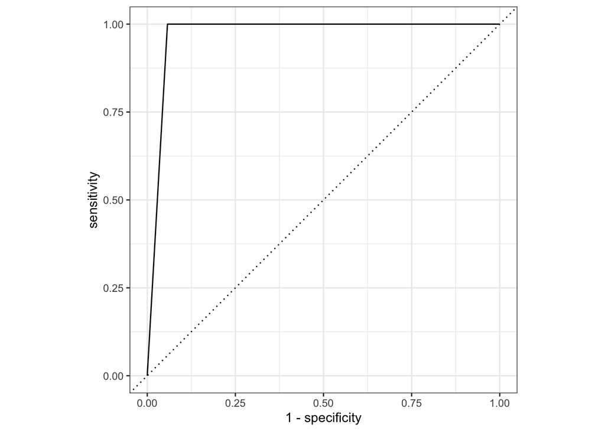

```r
#setting up log reg model
log_reg <- logistic_reg() %>%
  set_engine("glm") %>%
  set_mode("classification")

#setting up workflows
logreg_wkflow <- workflow() %>%
  add_model(log_reg) %>%
  add_recipe(label_recipe)

#Fitting to training dataset -- commented out so we don't need to re-train, just load. Same goes for KNN and Random Forest models.
#logreg_fit <- fit(logreg_wkflow, data_train)
#save(logreg_fit, file = "logreg_fit.rda")
load("logreg_fit.rda")

#plotting ROC curve
augresults <- augment(logreg_fit, new_data = data_test)
augresults %>%
  mutate(.pred_class = as.numeric(.pred_class)) %>%
  roc_curve(label, .pred_class, event_level = "second") %>%
  autoplot()
```

```r
#assessing the model
augresults$label <- as.numeric(augresults$label)
augresults$.pred_class <- as.numeric(augresults$.pred_class)
roc_object <- roc(augresults$label, augresults$.pred_class )
roc_object
```

```
##
## Call:
## roc.default(response = augresults$label, predictor = augresults$.pred_class)
##
## Data: augresults$.pred_class in 244 controls (augresults$label 1) < 150 cases (augresults$label 2).
## Area under the curve: 0.9713
```

The same steps are repeated for KNN, and we tune the hyperparameter neighbors first to determine the best hyperparameter, neighbors = 2.

```r
knn_model <- nearest_neighbor(neighbors = tune()) %>%
  set_mode("classification") %>%
  set_engine("kknn")
knn_wf <- workflow() %>%
  add_recipe(label_recipe) %>%
  add_model(knn_model)

#tuning grid for knn
knn_grid <- grid_regular(neighbors(range = c(1, 10)), levels = 10)

# # Perform grid search with cross-validation
# tune_knn <- tune_grid(
#   object = knn_wf,
#   resamples = folds,
#   grid = knn_grid
# )

# # Get the optimal value for neighbors
# best_neighbors <- select_best(tune_knn, metric = "accuracy") %>%
#   pull(neighbors)
# best_neighbors
```

We repeat the steps from before with the best hyperparameter. The results show that roc_auc is 0.5, which is very bad. This means that the model is no better than random guessing.

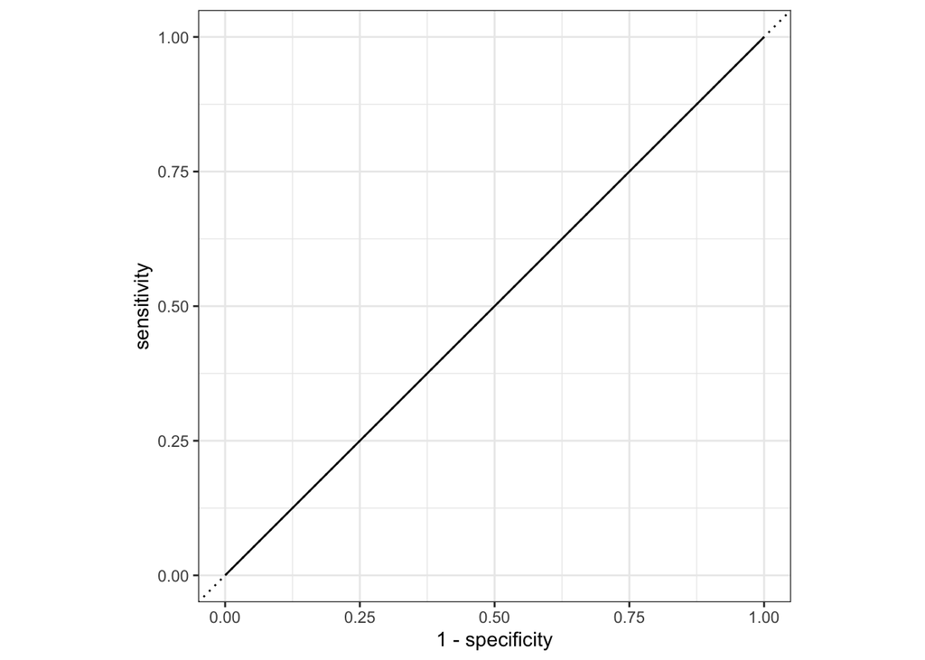

```r
knn_model <- nearest_neighbor(neighbors = 2) %>%
  set_mode("classification") %>%
  set_engine("kknn")
# knn_fit <- fit(knn_wf, data_train)
#save(knn_fit, file = "knn_fit.rda")
load("knn_fit.rda")

#plotting ROC curve
knnaugresults <- augment(knn_fit, new_data = data_test)
knnaugresults %>%
  mutate(.pred_class = as.numeric(.pred_class)) %>%
  roc_curve(label, .pred_class, event_level = "second") %>%
  autoplot()
```

```r
#assessing the model
knnaugresults$label <- as.numeric(knnaugresults$label)
knnaugresults$.pred_class <- as.numeric(knnaugresults$.pred_class)
knnroc_object <- roc(knnaugresults$label, knnaugresults$.pred_class )
knnroc_object
```

```
##
## Call:
## roc.default(response = knnaugresults$label, predictor = knnaugresults$.pred_class)
##
## Data: knnaugresults$.pred_class in 244 controls (knnaugresults$label 1) < 150 cases (knnaugresults$label 2).
## Area under the curve: 0.5
```

Now we perform the random forest model. We build the model, set up a workflow, create a grid, and tune. Then, after getting the best hyperparameters and choosing the best model we can assess it’s roc_auc and compare if it is better than the other models.

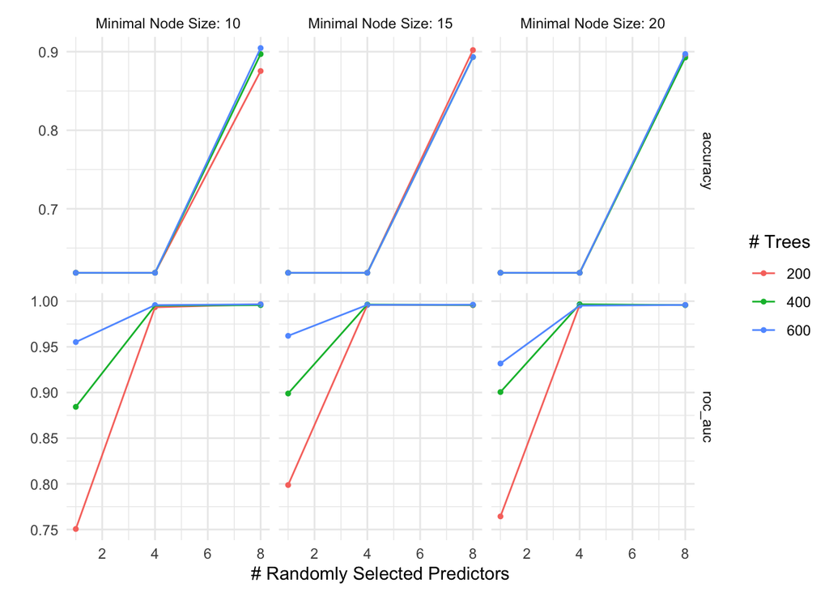

```r
rf <- rand_forest(mtry = tune(),
                    trees = tune(),
                    min_n = tune()) %>%
  set_engine("ranger", importance = "impurity") %>%
  set_mode("classification")

rf_wf <- workflow() %>%
  add_model(rf) %>%
  add_recipe(label_recipe)

#create grid
reggrid <- grid_regular(mtry(range = c(1, 8)), trees(range = c(200, 600)), min_n(range = c(10, 20)),levels = 3)

#tune random forest
#tune_rf <- tune_grid(
#  rf_wf,
#  resamples = folds,
#  grid = reggrid
#)

#save(tune_rf, file = "tune_rf.rda")
load("tune_rf.rda")

autoplot(tune_rf) + theme_minimal()
```

```r
#showing best random forest tuned parameters
show_best(tune_rf, n = 1)
```

```
## # A tibble: 1 × 9
##    mtry trees min_n .metric .estimator  mean     n std_err .config
##   <int> <int> <int> <chr>   <chr>      <dbl> <int>   <dbl> <chr>
## 1     4   400    20 roc_auc binary     0.997    10 0.00134 Preprocessor1_Model23
```

```r
best_rf_reg <- select_best(tune_rf)
#finalizing workflow of best random forest model
final_wf_rf <- finalize_workflow(rf_wf, best_rf_reg)
final_fit_rf <- fit(final_wf_rf, data_train)
final_fit_rf
```

```
## ══ Workflow [trained] ══════════════════════════════════════════════════════════
## Preprocessor: Recipe
## Model: rand_forest()
##
## ── Preprocessor ────────────────────────────────────────────────────────────────
## 1 Recipe Step
##
## • step_dummy()
##
## ── Model ───────────────────────────────────────────────────────────────────────
## Ranger result
##
## Call:
##  ranger::ranger(x = maybe_data_frame(x), y = y, mtry = min_cols(~4L,      x), num.trees = ~400L, min.node.size = min_rows(~20L, x),      importance = ~"impurity", num.threads = 1, verbose = FALSE,      seed = sample.int(10^5, 1), probability = TRUE)
##
## Type:                             Probability estimation
## Number of trees:                  400
## Sample size:                      1573
## Number of independent variables:  1656
## Mtry:                             4
## Target node size:                 20
## Variable importance mode:         impurity
## Splitrule:                        gini
## OOB prediction error (Brier s.):  0.2049919
```

```r
prob_predictions <- predict(final_fit_rf, new_data = data_test, type = "prob")

# add the truth column to the predictions
prob_predictions <- prob_predictions %>% bind_cols(data_test %>% dplyr::select(label))

# plot the ROC curve
truth <- as.numeric(as.character(prob_predictions$label))
roc_obj <- roc(truth, prob_predictions$.pred_1)
roc_obj
```

```
##
## Call:
## roc.default(response = truth, predictor = prob_predictions$.pred_1)
##
## Data: prob_predictions$.pred_1 in 244 controls (truth 0) < 150 cases (truth 1).
## Area under the curve: 0.9996
```

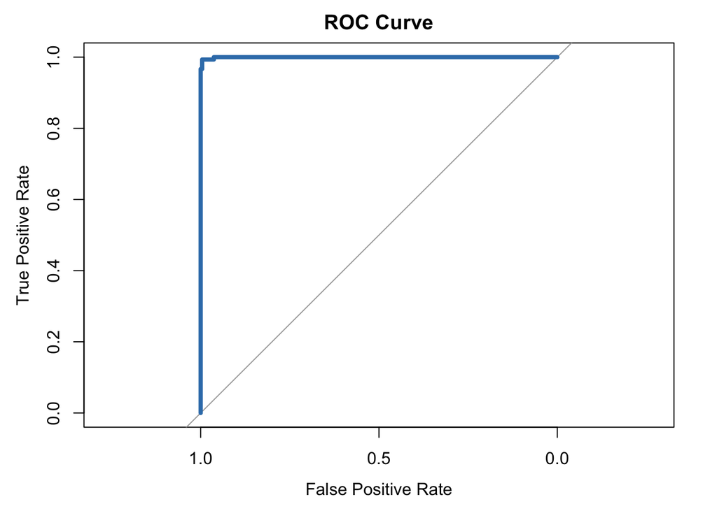

```r
plot(roc_obj, main="ROC Curve", xlab="False Positive Rate", ylab="True Positive Rate", col="#377eb8", lwd=4)
```

### Implementing a neural network

Now I will implement a neural network that includes article text and title, using the processed article text: text_without_stopwords. Stopwords are simple words like “the”, “a”, etc which won’t provide any value to the prediction training and testing, so these are removed ahead of time.

First, we load and preprocess the data.

```r
#create tokenizer object, keeping a maximum of 10,000 unique words
tokenizer <- text_tokenizer(num_words = 10000) %>% fit_text_tokenizer(data$text_without_stopwords)
#converts the text data into sequences of integars
sequences <- texts_to_sequences(tokenizer, data$text_without_stopwords)
#sequence padding -- ensures all have same length to length of 500
data_nn <- pad_sequences(sequences, maxlen = 500)
```

Next, we prepare the labels

```r
labels <- as.numeric(data$label)
# make it '0' and '1' instead of '1' and '2'
labels <- labels - 1
```

### Splitting train and testing and validation data

Once again, we will split the data for train and validation at 80-20 for predicting label.

```r
indices <- 1:nrow(data_nn)
train_indices <- sample(indices, size = floor(0.8 * length(indices)))
val_indices <- setdiff(indices, train_indices)

x_train <- data_nn[train_indices, ]
y_train <- labels[train_indices]

x_val <- data_nn[val_indices, ]
y_val <- labels[val_indices]
```

### Making the neural net layers

Now we will build the model. Neural networks have layers within the model and are filtered by activation functions. Relu makes everything nonnegative, and the sigmoid function will separate the binary outcome results.

```r
model <- keras_model_sequential() %>%
  layer_embedding(input_dim = 10000, output_dim = 32, input_length = 500) %>%
  layer_flatten() %>%
  layer_dense(units = 32, activation = 'relu') %>%
  layer_dense(units = 1, activation = 'sigmoid')  # '1' for binary classification, 'sigmoid' activation
```

Now I will compile the model with an optimizer and a loss function. For a binary classification problem like this, I used the loss function ‘binary_crossentropy’. A loss function, or a cost function, is a measure of how well a machine learning model is performing during training. It evaluates the difference between the predicted outputs of the model and the true values in the training data. ‘epochs’ is the number of times the learning algorithm will work through the entire training dataset, and ‘batch_size’ is the number of samples to work through before the model’s internal parameters are updated.

```r
model %>% compile(
  optimizer = 'adam',
  loss = 'binary_crossentropy',
  metrics = c('accuracy')
)
```

### Training the model

Now I am fitting the model to the training data. ‘epochs’ is the number of times the learning algorithm will work through the entire training dataset, and ‘batch_size’ is the number of samples to work through before the model’s internal parameters are updated.

```r
history <- model %>% fit(
  x_train, y_train,
  epochs = 10,
  batch_size = 32,
  validation_data = list(x_val, y_val)
)
```

```r
model %>% evaluate(x_val, y_val)
```

```
##      loss  accuracy
## 0.5904452 0.6827411
```

### Make predictions

After evaluating the performance of the model, I will use the model to make predictions on new data.

```r
new_sequences <- texts_to_sequences(tokenizer, "billion even after they are known to be keeping all supposedly deleted messages in their server well i guess they need to somehow profitprobably selling content to rich blackmailers")
new_data <- pad_sequences(new_sequences, maxlen = 500)

predictions <- model %>% predict(new_data) %>% `>`(0.5) %>% k_cast("int32")

print(predictions)
```

```
## tf.Tensor([[1]], shape=(1, 1), dtype=int32)
```

### Conclusion

Overall in this project we have discovered and analyzed new findings in this dataset to build and test a model that predicts the realness or fakeness of a given article. The logistic regression had great roc_auc results, the KNN model had bad roc_auc results, and the random forest had the best roc_auc results.

Our best model still did very good! The model may not be perfect, but the results were very satisfactory in the end as an roc_auc above a .9 is excellent!